# Machine Learning to Identify Fraud in the Enron Corpus

```python
import warnings
warnings.filterwarnings("ignore")
import sys
import pickle
sys.path.append("../tools/")
from feature_format import featureFormat, targetFeatureSplit
from tester import dump_classifier_and_data
import pandas as pd
import sys
import pickle
import csv
import matplotlib.pyplot as plt

sys.path.append("../tools/")
from feature_format import featureFormat, targetFeatureSplit
#from poi_data import *
from sklearn.feature_selection import SelectKBest
from sklearn.pipeline import Pipeline
from sklearn.preprocessing import StandardScaler
from sklearn.model_selection import StratifiedShuffleSplit

from numpy import mean
from sklearn.model_selection import train_test_split
from sklearn.model_selection import cross_validate

from sklearn.metrics import accuracy_score, precision_score, recall_score
```

## Task 1: Select what features you'll use

features_list is a list of strings, each of which is a feature name.  
The first feature must be "poi".  
features_list = ['poi','salary']  
**You will need to use more features**

```python
target_label = 'poi'

email_features_list = [
    'from_messages',
    'from_poi_to_this_person',
    'from_this_person_to_poi',
    'shared_receipt_with_poi',
    'to_messages',
    ]

financial_features_list = [
    'bonus',
    'deferral_payments',
    'deferred_income',
    'director_fees',
    'exercised_stock_options',
    'expenses',
    'loan_advances',
    'long_term_incentive',
    'other',
    'restricted_stock',
    'restricted_stock_deferred',
    'salary',
    'total_payments',
    'total_stock_value',
]

features_list = [target_label] + financial_features_list + email_features_list
```

```python
### Load the dictionary containing the dataset

with open('final_project_dataset.pkl', 'rb') as data_file:
    data_dict = pickle.load(data_file)
```

```python
df = pd.DataFrame(data_dict)
df.T
```

|  | salary | to_messages | deferral_payments | total_payments | loan_advances | bonus | email_address | restricted_stock_deferred | deferred_income | total_stock_value | ... | from_poi_to_this_person | exercised_stock_options | from_messages | other | from_this_person_to_poi | poi | long_term_incentive | shared_receipt_with_poi | restricted_stock | director_fees |
| --- | --- | --- | --- | --- | --- | --- | --- | --- | --- | --- | --- | --- | --- | --- | --- | --- | --- | --- | --- | --- | --- |
| METTS MARK | 365788 | 807 | NaN | 1061827 | NaN | 600000 | mark.metts@enron.com | NaN | NaN | 585062 | ... | 38 | NaN | 29 | 1740 | 1 | False | NaN | 702 | 585062 | NaN |
| BAXTER JOHN C | 267102 | NaN | 1295738 | 5634343 | NaN | 1200000 | NaN | NaN | -1386055 | 10623258 | ... | NaN | 6680544 | NaN | 2660303 | NaN | False | 1586055 | NaN | 3942714 | NaN |
| ELLIOTT STEVEN | 170941 | NaN | NaN | 211725 | NaN | 350000 | steven.elliott@enron.com | NaN | -400729 | 6678735 | ... | NaN | 4890344 | NaN | 12961 | NaN | False | NaN | NaN | 1788391 | NaN |
| CORDES WILLIAM R | NaN | 764 | NaN | NaN | NaN | NaN | bill.cordes@enron.com | NaN | NaN | 1038185 | ... | 10 | 651850 | 12 | NaN | 0 | False | NaN | 58 | 386335 | NaN |
| HANNON KEVIN P | 243293 | 1045 | NaN | 288682 | NaN | 1500000 | kevin.hannon@enron.com | NaN | -3117011 | 6391065 | ... | 32 | 5538001 | 32 | 11350 | 21 | True | 1617011 | 1035 | 853064 | NaN |
| ... | ... | ... | ... | ... | ... | ... | ... | ... | ... | ... | ... | ... | ... | ... | ... | ... | ... | ... | ... | ... | ... |
| GRAMM WENDY L | NaN | NaN | NaN | 119292 | NaN | NaN | NaN | NaN | NaN | NaN | ... | NaN | NaN | NaN | NaN | NaN | False | NaN | NaN | NaN | 119292 |
| CAUSEY RICHARD A | 415189 | 1892 | NaN | 1868758 | NaN | 1000000 | richard.causey@enron.com | NaN | -235000 | 2502063 | ... | 58 | NaN | 49 | 307895 | 12 | True | 350000 | 1585 | 2502063 | NaN |
| TAYLOR MITCHELL S | 265214 | 533 | 227449 | 1092663 | NaN | 600000 | mitchell.taylor@enron.com | NaN | NaN | 3745048 | ... | 0 | 3181250 | 29 | NaN | 0 | False | NaN | 300 | 563798 | NaN |
| DONAHUE JR JEFFREY M | 278601 | 865 | NaN | 875760 | NaN | 800000 | jeff.donahue@enron.com | NaN | -300000 | 1080988 | ... | 188 | 765920 | 22 | 891 | 11 | False | NaN | 772 | 315068 | NaN |
| GLISAN JR BEN F | 274975 | 873 | NaN | 1272284 | NaN | 600000 | ben.glisan@enron.com | NaN | NaN | 778546 | ... | 52 | 384728 | 16 | 200308 | 6 | True | 71023 | 874 | 393818 | NaN |

146 rows × 21 columns

### 1.1.0 Explore csv file

```python
def make_csv(data_dict):
    """ generates a csv file from a data set"""
    fieldnames = ['name'] + data_dict.itervalues().next().keys()
    with open('data.csv', 'w') as csvfile:
        writer = csv.DictWriter(csvfile, fieldnames=fieldnames)
        writer.writeheader()
        for record in data_dict:
            person = data_dict[record]
            person['name'] = record
            assert set(person.keys()) == set(fieldnames)
            writer.writerow(person)
```

### 1.1.1 Dataset Exploration

```python
print('# Exploratory Data Analysis #')
data_dict.keys()
print('Total number of data points: %d' % len(data_dict.keys()))
num_poi = 0
for name in data_dict.keys():
    if data_dict[name]['poi'] == True:
        num_poi += 1
print('Number of Persons of Interest: %d' % num_poi)
print('Number of people without Person of Interest label: %d' % (len(data_dict.keys()) - num_poi))
```

```
# Exploratory Data Analysis #
Total number of data points: 146
Number of Persons of Interest: 18
Number of people without Person of Interest label: 128
```

### 1.1.2 Feature Exploration

```python
all_features = data_dict['ALLEN PHILLIP K'].keys()
print('Each person has %d features available' %  len(all_features))
### Evaluate dataset for completeness
missing_values = {}
for feature in all_features:
    missing_values[feature] = 0
for person in data_dict.keys():
    records = 0
    for feature in all_features:
        if data_dict[person][feature] == 'NaN':
            missing_values[feature] += 1
        else:
            records += 1
```

```
Each person has 21 features available
```

### Print results of completeness analysis

```python
print('Number of Missing Values for Each Feature:')

#sorted(missing_values.values())

#for feature in all_features:
   # print("%s: %d" % (feature, sorted(missing_values.values())[feature])


for id in sorted(missing_values, key = missing_values.get, reverse = True):
          print(id, missing_values[id])
```

```
Number of Missing Values for Each Feature:
loan_advances 142
director_fees 129
restricted_stock_deferred 128
deferral_payments 107
deferred_income 97
long_term_incentive 80
bonus 64
to_messages 60
from_poi_to_this_person 60
from_messages 60
from_this_person_to_poi 60
shared_receipt_with_poi 60
other 53
salary 51
expenses 51
exercised_stock_options 44
restricted_stock 36
email_address 35
total_payments 21
total_stock_value 20
poi 0
```

=> classification,we have here unblanced target. Maybe Smot methodology ?

## Task 2: Remove outliers

```python
def PlotOutlier(data_dict, feature_x, feature_y):
    """ Plot with flag = True in Red """
    data = featureFormat(data_dict, [feature_x, feature_y, 'poi'])
    for point in data:
        x = point[0]
        y = point[1]
        poi = point[2]
        if poi:
            color = 'red'
        else:
            color = 'blue'
        plt.scatter(x, y, color=color)
    plt.xlabel(feature_x)
    plt.ylabel(feature_y)
    plt.show()
```

### 2.1 Visualise outliers

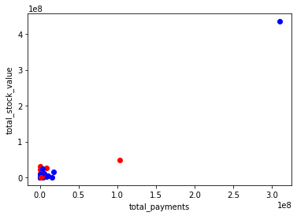

```
None
```

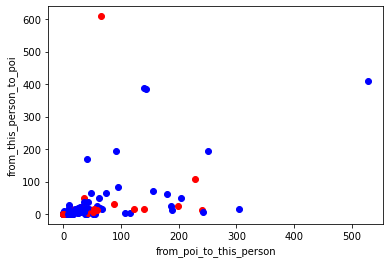

```
None
```

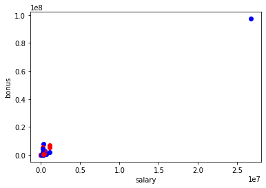

```
None
```

```
{'salary': 26704229,
 'to_messages': 'NaN',
 'deferral_payments': 32083396,
 'total_payments': 309886585,
 'loan_advances': 83925000,
 'bonus': 97343619,
 'email_address': 'NaN',
 'restricted_stock_deferred': -7576788,
 'deferred_income': -27992891,
 'total_stock_value': 434509511,
 'expenses': 5235198,
 'from_poi_to_this_person': 'NaN',
 'exercised_stock_options': 311764000,
 'from_messages': 'NaN',
 'other': 42667589,
 'from_this_person_to_poi': 'NaN',
 'poi': False,
 'long_term_incentive': 48521928,
 'shared_receipt_with_poi': 'NaN',
 'restricted_stock': 130322299,
 'director_fees': 1398517}
```

```python
print(PlotOutlier(data_dict, 'total_payments', 'total_stock_value'))
print(PlotOutlier(data_dict, 'from_poi_to_this_person', 'from_this_person_to_poi'))
print(PlotOutlier(data_dict, 'salary', 'bonus'))
#Remove outlier TOTAL line in pickle file.
data_dict.pop( 'TOTAL', 0 )
```

### 2.2 Function to remove outliers

```python
def remove_outlier(dict_object, keys):
    """ removes list of outliers keys from dict object """
    for key in keys:
        dict_object.pop(key, 0)

outliers = ['TOTAL', 'THE TRAVEL AGENCY IN THE PARK', 'LOCKHART EUGENE E']
remove_outlier(data_dict, outliers)
```

### Task 3: Create new feature(s)

### 3.1 create new copies of dataset for grading

```python
my_dataset = data_dict
```

### 3.2 add new features to dataset

```python
def compute_fraction(x, y):
    """ return fraction of messages from/to that person to/from POI"""
    if x == 'NaN' or y == 'NaN':
        return 0.
    if x == 0 or y == 0:
        return 0
    fraction = x / y
    return fraction

def compute_ratio(poi_from, poi_to,messages_from, messages_to):
    """ return fraction of messages from/to that person to/from POI"""
    if poi_from == 'NaN' or poi_to == 'NaN' or messages_from =='NaN' or messages_to=='NaN':
        return 0.
    fraction =  (poi_from + poi_to)/(messages_from + messages_to)
    return fraction
```

By doing further research on the data and its source, we have learned that NaN values in financial and stock columns do not mean a lack of information but a zero value. So we will for each one of its columns replaced the NaN values by zeros.

```python
for name in my_dataset:
    data_point = my_dataset[name]
    NaN_value = 0
    if data_point['deferral_payments'] == 'NaN' :
        data_point['deferral_payments'] = NaN_value

    if data_point['total_payments'] == 'NaN' :
        data_point['total_payments'] = NaN_value

    if data_point['loan_advances'] == 'NaN':
        data_point['loan_advances'] = NaN_value

    if data_point['bonus'] == 'NaN' :
        data_point['bonus'] = NaN_value

    if data_point['restricted_stock_deferred'] == 'NaN':
        data_point['restricted_stock_deferred'] = NaN_value

    if data_point['total_stock_value'] == 'NaN' :
        data_point['total_stock_value'] = NaN_value

    if data_point['expenses'] == 'NaN' :
        data_point['expenses'] = NaN_value

    if data_point['exercised_stock_options'] == 'NaN' :
        data_point['exercised_stock_options'] = NaN_value

    if data_point['long_term_incentive'] == 'NaN' :
        data_point['long_term_incentive'] = NaN_value

    if data_point['director_fees'] == 'NaN' :
        data_point['director_fees'] = NaN_value

    if data_point['director_fees'] == 'NaN' :
        data_point['director_fees'] = NaN_value
```

```python
my_dataset.pop('FREVERT MARK A')
my_dataset.pop('LAVORATO JOHN J')
my_dataset.pop('WHALLEY LAWRENCE G')
my_dataset.pop('BAXTER JOHN C')
```

```
{'salary': 267102,
 'to_messages': 'NaN',
 'deferral_payments': 1295738,
 'total_payments': 5634343,
 'loan_advances': 0,
 'bonus': 1200000,
 'email_address': 'NaN',
 'restricted_stock_deferred': 0,
 'deferred_income': -1386055,
 'total_stock_value': 10623258,
 'expenses': 11200,
 'from_poi_to_this_person': 'NaN',
 'exercised_stock_options': 6680544,
 'from_messages': 'NaN',
 'other': 2660303,
 'from_this_person_to_poi': 'NaN',
 'poi': False,
 'long_term_incentive': 1586055,
 'shared_receipt_with_poi': 'NaN',
 'restricted_stock': 3942714,
 'director_fees': 0}
```

In addition, we decided to replace the NaN values in the message columns with the average based on POI and non-POI employees. This will allow us to feed more information to our models.

```python
cnt_from_poi_to_this_person =0
cnt_from_this_person_to_poi=0
cnt_to_messages =0
cnt_from_messages =0
cnt_shared_receipt_with_poi = 0

cnt_poi_from_poi_to_this_person =0
cnt_poi_from_this_person_to_poi=0
cnt_poi_to_messages =0
cnt_poi_from_messages =0
cnt_poi_shared_receipt_with_poi = 0

sum_poi_from_poi_to_this_person =0
sum_poi_from_this_person_to_poi=0
sum_poi_to_messages =0
sum_poi_from_messages =0
sum_shared_receipt_with_poi = 0

sum_from_poi_to_this_person =0
sum_from_this_person_to_poi=0
sum_to_messages =0
sum_from_messages =0
sum_poi_shared_receipt_with_poi = 0

for name in my_dataset:

    data_point = my_dataset[name]
    from_poi_to_this_person = data_point["from_poi_to_this_person"]
    from_messages = data_point['from_messages']
    to_messages = data_point['to_messages']
    from_this_person_to_poi = data_point["from_this_person_to_poi"]
    poi = data_point["poi"]
    shared_receipt_with_poi = data_point["shared_receipt_with_poi"]

    if from_messages != 'NaN' and poi ==False:
        cnt_from_messages += 1
        sum_from_messages += from_messages
    elif from_messages != 'NaN' and poi ==True:
        cnt_poi_from_messages +=1
        sum_poi_from_messages += from_messages

    if to_messages != 'NaN' and poi ==False:
        cnt_to_messages += 1
        sum_to_messages += to_messages
    elif to_messages != 'NaN' and poi ==True:
        cnt_poi_to_messages +=1
        sum_poi_to_messages += to_messages

    if from_poi_to_this_person != 'NaN' and poi ==False:
        cnt_from_poi_to_this_person += 1
        sum_from_poi_to_this_person += from_poi_to_this_person
    elif from_messages != 'NaN' and poi ==True:
        cnt_poi_from_poi_to_this_person +=1
        sum_poi_from_poi_to_this_person+= from_poi_to_this_person

    if from_this_person_to_poi != 'NaN' and poi ==False:
        cnt_from_this_person_to_poi += 1
        sum_from_this_person_to_poi += from_this_person_to_poi
    elif from_messages != 'NaN' and poi ==True:
        cnt_poi_from_this_person_to_poi +=1
        sum_poi_from_this_person_to_poi += from_this_person_to_poi

    if shared_receipt_with_poi != 'NaN' and poi ==False:
        cnt_shared_receipt_with_poi += 1
        sum_shared_receipt_with_poi += shared_receipt_with_poi
    elif shared_receipt_with_poi != 'NaN' and poi ==True:
        cnt_poi_shared_receipt_with_poi +=1
        sum_poi_shared_receipt_with_poi += shared_receipt_with_poi


mean_from_poi_to_this_person = compute_fraction(sum_from_poi_to_this_person,cnt_from_poi_to_this_person)
mean_from_this_person_to_poi= compute_fraction(sum_from_this_person_to_poi, cnt_from_this_person_to_poi)
mean_to_messages =compute_fraction(sum_to_messages,cnt_to_messages)
mean_from_messages =compute_fraction(sum_from_messages,cnt_from_messages)
mean_shared_receipt_with_poi = compute_fraction(sum_shared_receipt_with_poi,cnt_shared_receipt_with_poi)

mean_poi_from_poi_to_this_person = compute_fraction(sum_poi_from_poi_to_this_person,cnt_poi_from_poi_to_this_person)
mean_poi_from_this_person_to_poi= compute_fraction(sum_poi_from_this_person_to_poi, cnt_poi_from_this_person_to_poi)
mean_poi_to_messages =compute_fraction(sum_poi_to_messages,cnt_poi_to_messages)
mean_poi_from_messages =compute_fraction(sum_poi_from_messages,cnt_poi_from_messages)
mean_poi_shared_receipt_with_poi = compute_fraction(sum_poi_shared_receipt_with_poi,cnt_poi_shared_receipt_with_poi)

for name in my_dataset:

    data_point = my_dataset[name]
    from_poi_to_this_person = data_point["from_poi_to_this_person"]
    from_messages = data_point['from_messages']
    to_messages = data_point['to_messages']
    from_this_person_to_poi = data_point["from_this_person_to_poi"]
    shared_receipt_with_poi = data_point["shared_receipt_with_poi"]
    poi = data_point["poi"]

    if from_messages == 'NaN' and poi ==False:
        data_point["from_messages"] = mean_from_messages
    elif from_messages == 'NaN' and poi ==True:
        data_point["from_messages"] = mean_poi_from_messages

    if to_messages == 'NaN' and poi ==False:
        data_point["to_messages"]== mean_to_messages
    elif to_messages == 'NaN' and poi ==True:
        data_point["to_messages"] = mean_poi_to_messages

    if from_poi_to_this_person == 'NaN' and poi ==False:
        data_point["from_poi_to_this_person"]  =mean_from_poi_to_this_person
    elif from_messages == 'NaN' and poi ==True:
        data_point["from_poi_to_this_person"]  = mean_poi_from_poi_to_this_person

    if from_this_person_to_poi == 'NaN' and poi ==False:
        data_point["from_this_person_to_poi"]  =mean_from_this_person_to_poi
    elif from_messages == 'NaN' and poi ==True:
        data_point["from_this_person_to_poi"]= mean_poi_from_this_person_to_poi

    if shared_receipt_with_poi == 'NaN' and poi ==False:
        data_point["shared_receipt_with_poi"]  =  mean_shared_receipt_with_poi
    elif from_messages == 'NaN' and poi ==True:
        data_point["shared_receipt_with_poi"]= mean_poi_shared_receipt_with_poi
```

```python
print(mean_from_poi_to_this_person , mean_from_this_person_to_poi, mean_to_messages , mean_from_messages)
print(mean_poi_from_poi_to_this_person , mean_poi_from_this_person_to_poi , mean_poi_to_messages,mean_poi_from_messages )
```

```
47.18840579710145 31.463768115942027 1854.4782608695652 652.0144927536232
97.78571428571429 66.71428571428571 2417.1428571428573 300.35714285714283
```

We add new ratio features :

1. shared_recepeit with poi
2. bonus_to_salary
3. payments_to_salary
4. ratio mess
5. exercised_stock_options
6. bonus_to_total

```python
for name in my_dataset:
    data_point = my_dataset[name]
    from_poi_to_this_person = data_point["from_poi_to_this_person"]
    to_messages = data_point["to_messages"]
    fraction_from_poi = compute_fraction(from_poi_to_this_person, to_messages)
    data_point["fraction_from_poi"] = fraction_from_poi
    from_this_person_to_poi = data_point["from_this_person_to_poi"]
    from_messages = data_point["from_messages"]
    fraction_to_poi = compute_fraction(from_this_person_to_poi, from_messages)
    data_point["fraction_to_poi"] = fraction_to_poi

    shared_receipt_with_poi = data_point["shared_receipt_with_poi"]
    shared_receipt_poi_ratio = compute_fraction(shared_receipt_with_poi, to_messages)
    data_point["shared_receipt_poi_ratio"] = shared_receipt_poi_ratio

    bonus= data_point["bonus"]
    salary = data_point["salary"]
    bonus_to_salary = compute_fraction(bonus, salary)
    data_point["bonus_to_salary"] = bonus_to_salary

    total_payments = data_point["total_payments"]
    bonus_to_total = compute_fraction(bonus, total_payments)
    data_point["bonus_to_total"] = bonus_to_total

    exercised_stock_options= data_point["exercised_stock_options"]
    total_stock_value= data_point["total_stock_value"]
    exercised_stock_options_ratio = compute_fraction(exercised_stock_options, total_stock_value)
    data_point["exercised_stock_options_ratio"] = exercised_stock_options_ratio

    ratio_mess= compute_ratio(from_poi_to_this_person, from_this_person_to_poi,from_messages, to_messages)
    data_point["ratio_mess"] = ratio_mess
```

Finally, while inquiring we found the members of the board and we wanted to add a feature where we indicate on a person is part of the board.

```python
for name in my_dataset:
    data_point = my_dataset[name]
    direction = 0
    data_point["direction"] = direction
```

```python
list_direction2 = ["LAY KENNETH L","SKILLING JEFFREY K"]
list_direction1 = ["BUY RICHARD B","CAUSEY RICHARD A","DERRICK JR. JAMES V","KEAN STEVEN J","KOENIG MARK E","METTS MARK","FASTOW ANDREW S","BAXTER JOHN C","HORTON STANLEY C","FREVERT MARK A","WHALLEY LAWRENCE G","PAI LOU L","WHITE JR THOMAS E","HIRKO JOSEPH","RICE KENNETH D"]
data_point = my_dataset[name]
for name in my_dataset :
    for item in list_direction1 :
        if name == item :
            direction = 1
            my_dataset[name]['direction'] = direction
    for item2 in list_direction2 :
        if name == item2 :
            direction = 2
            my_dataset[name]['direction'] = direction
```

### 3.3 create new copies of feature list for grading

```python
my_feature_list = features_list +[ 'fraction_to_poi','shared_receipt_poi_ratio','bonus_to_salary','bonus_to_total','direction','ratio_mess','exercised_stock_options_ratio']
```

```python
features_list
```

```
['poi',
 'bonus',
 'deferral_payments',
 'deferred_income',
 'director_fees',
 'exercised_stock_options',
 'expenses',
 'loan_advances',
 'long_term_incentive',
 'other',
 'restricted_stock',
 'restricted_stock_deferred',
 'salary',
 'total_payments',
 'total_stock_value',
 'from_messages',
 'from_poi_to_this_person',
 'from_this_person_to_poi',
 'shared_receipt_with_poi',
 'to_messages']
```

### 3.4 get K-best features

```python
num_features = 10
```

### 3.5 function using SelectKBest

```python
def get_k_best(data_dict, features_list, k):
    """ runs scikit-learn's SelectKBest feature selection
        returns dict where keys=features, values=scores
    """
    data = featureFormat(data_dict, features_list)
    labels, features = targetFeatureSplit(data)
    k_best = SelectKBest(k=k)
    k_best.fit(features, labels)
    scores = k_best.scores_
    print(scores)
    unsorted_pairs = zip(features_list[1:], scores)
    sorted_pairs = list(reversed(sorted(unsorted_pairs, key=lambda x: x[1])))
    k_best_features = dict(sorted_pairs[:k])
    print ("{0} best features: {1}\n".format(k, k_best_features.keys(), scores))
    return k_best_features
```

=> Maybe appropriate stat test for classification.

```python
best_features = get_k_best(my_dataset, my_feature_list, num_features)
my_feature_list = [target_label] + list(set(best_features.keys()))
```

```
[3.57816913e+01 6.23357612e-02 1.69571949e+01 2.20445373e+00
 2.65605672e+01 6.27032312e+00 7.00482086e+00 1.25623996e+01
 7.79759949e+00 1.03730946e+01 6.76455637e-02 2.51041513e+01
 9.53332413e+00 2.64658715e+01 9.40072407e-01 1.58934237e+01
 3.82537238e+00 1.65350818e+01 6.39951658e+00 2.58998284e+01
 2.66240943e+01 1.67813465e+01 2.06120518e+01 2.78013676e+01
 1.41779001e+01 2.19449948e-02]
10 best features: dict_keys(['bonus', 'direction', 'shared_receipt_poi_ratio', 'exercised_stock_options', 'total_stock_value', 'fraction_to_poi', 'salary', 'bonus_to_total', 'deferred_income', 'bonus_to_salary'])
```

### 3.6 print features

```python
print ("{0} selected features: {1}\n".format(len(my_feature_list) - 1, my_feature_list[1:]))
```

```
10 selected features: ['exercised_stock_options', 'shared_receipt_poi_ratio', 'total_stock_value', 'salary', 'deferred_income', 'direction', 'bonus_to_total', 'bonus', 'fraction_to_poi', 'bonus_to_salary']
```

### 3.7 extract the features specified in features_list

```python
data = featureFormat(my_dataset, my_feature_list,sort_keys = True)
```

split into labels and features

```python
labels, features = targetFeatureSplit(data)
```

### 3.8 scale features via min-max

```python
from sklearn import preprocessing
scaler = preprocessing.MinMaxScaler()
features = scaler.fit_transform(features)
```

## Task 4: Using algorithm

Please name your classifier clf for easy export below.  
Note that if you want to do PCA or other multi-stage operations,  
you'll need to use Pipelines. For more info:  
http://scikit-learn.org/stable/modules/pipeline.html

Provided to give you a starting point. Try a variety of classifiers.

### 4.1 Gaussian Naive Bayes Classifier

```python
from sklearn.naive_bayes import GaussianNB
g_clf = GaussianNB()
```

### 4.2 Logistic Regression Classifier

```python
from sklearn.linear_model import LogisticRegression
```

```python
l_clf = Pipeline(steps= [
        ('scaler', StandardScaler()),
        ('classifier', LogisticRegression(C=1e-08, class_weight=None, dual=False, fit_intercept=True, intercept_scaling=1,
max_iter=100, multi_class='ovr', penalty='l2', random_state=42, solver='liblinear', tol=0.001, verbose=0))])
```

### 4.3 K-means Clustering

```python
from sklearn.cluster import KMeans
k_clf = KMeans(n_clusters=2, tol=0.001)
```

### 4.4 Support Vector Machine Classifier

```python
from sklearn.svm import SVC
s_clf = SVC(kernel='rbf', C=1000,gamma = 0.0001,random_state = 42, class_weight = 'balanced')
```

### 4.5 Random Forest

```python
from sklearn.ensemble import RandomForestClassifier
rf_clf = RandomForestClassifier(max_depth = 5,max_features = 'sqrt',n_estimators = 10, random_state = 42)
```

### 4.6 Gradient Boosting Classifier

```python
from sklearn.ensemble  import GradientBoostingClassifier
gb_clf = GradientBoostingClassifier(loss='deviance', learning_rate=0.1, n_estimators=10,random_state = 42)
```

### 4.7 Decision Tree Classifier

```python
from sklearn.tree import DecisionTreeClassifier
```

```python
tre_clf=DecisionTreeClassifier(random_state=42)
```

### 4.8 KNeighborsClassifier

```python
from sklearn.neighbors import KNeighborsClassifier
```

```python
knn_clf = KNeighborsClassifier(n_neighbors=3)
```

### 4.9 Perceptron

```python
from sklearn.linear_model import Perceptron
pe_clf= Perceptron(max_iter=5)
```

### 4.10 MLP Perceptron

```python
from sklearn.neural_network import MLPClassifier
```

```python
mlp_clf = MLPClassifier(random_state=1)
```

### 4.9 evaluate function

```python
from imblearn.over_sampling import SMOTE
from imblearn.combine import SMOTETomek
from sklearn.model_selection import StratifiedShuffleSplit
sss = StratifiedShuffleSplit(n_splits=1, test_size=0.1, random_state=0)
```

```python
def evaluate_clf(clf, features, labels, num_iters=1000, test_size=0.3):
    print (clf)
    accuracy = []
    precision = []
    recall = []
    first = True
    for trial in range(num_iters):
        features_train, features_test, labels_train, labels_test =\
            train_test_split(features, labels, test_size=test_size)
        clf.fit(features_train,labels_train)
        predictions = clf.predict(features_test)
        accuracy.append(accuracy_score(labels_test, predictions))
        precision.append(precision_score(labels_test, predictions))
        recall.append(recall_score(labels_test, predictions))
        if trial % 10 == 0:
            if first:
                sys.stdout.write('\nProcessing')
            sys.stdout.write('.')
            sys.stdout.flush()
            first = False

    print ("done.\n")
    print ("precision: {}".format(mean(precision)))
    print ("recall:    {}".format(mean(recall)))
    print ("accuracy:    {}".format(mean(accuracy)))
    return len(labels_test)
    return mean(precision), mean(recall)
```

### 4.8 Evaluate all functions

```python
evaluate_clf(g_clf, features, labels)
evaluate_clf(l_clf, features, labels)
evaluate_clf(k_clf, features, labels)
evaluate_clf(s_clf, features, labels)
evaluate_clf(rf_clf, features, labels)
evaluate_clf(gb_clf, features, labels)
evaluate_clf(tre_clf, features, labels)
evaluate_clf(knn_clf, features, labels)
evaluate_clf(pe_clf, features, labels)
evaluate_clf(mlp_clf, features, labels)
```

```
GaussianNB()

Processing....................................................................................................done.

precision: 0.5490830835830837
recall:    0.49529473304473304
accuracy:    0.8770238095238096
Pipeline(steps=[('scaler', StandardScaler()),
                ('classifier',
                 LogisticRegression(C=1e-08, multi_class='ovr', random_state=42,
                                    solver='liblinear', tol=0.001))])

Processing....................................................................................................done.

precision: 0.44131190169050083
recall:    0.7463699494949495
accuracy:    0.8372857142857144
KMeans(n_clusters=2, tol=0.001)

Processing....................................................................................................done.

precision: 0.16048605562519164
recall:    0.5729059523809524
accuracy:    0.5205952380952381
SVC(C=1000, class_weight='balanced', gamma=0.0001, random_state=42)

Processing....................................................................................................done.

precision: 0.29622454900508477
recall:    0.9383534992784994
accuracy:    0.6956190476190476
RandomForestClassifier(max_depth=5, max_features='sqrt', n_estimators=10,
                       random_state=42)

Processing....................................................................................................done.

precision: 0.5915753968253968
recall:    0.32965479797979796
accuracy:    0.8815000000000001
GradientBoostingClassifier(n_estimators=10, random_state=42)
```

[output cut: 19 more lines]

```
accuracy:    0.8535952380952383
Perceptron(max_iter=5)

Processing....................................................................................................done.

precision: 0.5118969719595745
recall:    0.41979206349206344
accuracy:    0.8469761904761905
MLPClassifier(random_state=1)

Processing....................................................................................................done.

precision: 0.6464571428571428
recall:    0.2864976911976912
accuracy:    0.8896428571428573
```

```
42
```

### 5. Hyperparameters tuning

```python
from sklearn.model_selection import GridSearchCV
import numpy as np
```

#### 5.1 Decision tree

We select one of the best model from the evaluate function, in order to tune the hyperparameters. As a reminder, here are the results obtained without tuning : precision: 0.4703893550893551 recall: 0.45136847041847045 accuracy: 0.858238095238095 First, we create a pipeline to run a GridSearch on the select K best as to find the best features selection number.

```python
n_features = np.arange(1, 20)
my_feature_list = features_list +['fraction_to_poi','shared_receipt_poi_ratio','bonus_to_salary','bonus_to_total','direction','ratio_mess','exercised_stock_options_ratio']
data = featureFormat(my_dataset, my_feature_list,sort_keys = True)
labels, features = targetFeatureSplit(data)
# Create a pipeline with feature selection and classification
pipe_k1 = Pipeline([
    ('select_features', SelectKBest()),
    ('classifier',DecisionTreeClassifier())])
param_grid = [
    {
        'select_features__k': n_features
    }
]

# Use GridSearchCV to automate the process of finding the optimal number of features

cv = StratifiedShuffleSplit(n_splits=10, test_size=0.3, random_state=67)
k_clf= GridSearchCV(pipe_k1, param_grid=param_grid, scoring='f1', cv = cv)
k_clf.fit(features, labels)
```

```
GridSearchCV(cv=StratifiedShuffleSplit(n_splits=10, random_state=67, test_size=0.3,
            train_size=None),
             estimator=Pipeline(steps=[('select_features', SelectKBest()),
                                       ('classifier',
                                        DecisionTreeClassifier())]),
             param_grid=[{'select_features__k': array([ 1,  2,  3,  4,  5,  6,  7,  8,  9, 10, 11, 12, 13, 14, 15, 16, 17,
       18, 19])}],
             scoring='f1')
```

```python
k_clf.best_score_
```

```
0.625053965642201
```

```python
k_clf.best_score_
k_clf.best_estimator_
```

```
Pipeline(steps=[('select_features', SelectKBest(k=18)),
                ('classifier', DecisionTreeClassifier())])
```

```python
num_features=19
```

```python
best_features = get_k_best(my_dataset, my_feature_list, num_features)
my_feature_list = [target_label] + list(set(best_features.keys()))
```

```
[3.57816913e+01 6.23357612e-02 1.69571949e+01 2.20445373e+00
 2.65605672e+01 6.27032312e+00 7.00482086e+00 1.25623996e+01
 7.79759949e+00 1.03730946e+01 6.76455637e-02 2.51041513e+01
 9.53332413e+00 2.64658715e+01 9.40072407e-01 1.58934237e+01
 3.82537238e+00 1.65350818e+01 6.39951658e+00 2.58998284e+01
 2.66240943e+01 1.67813465e+01 2.06120518e+01 2.78013676e+01
 1.41779001e+01 2.19449948e-02]
19 best features: dict_keys(['bonus', 'direction', 'shared_receipt_poi_ratio', 'exercised_stock_options', 'total_stock_value', 'fraction_to_poi', 'salary', 'bonus_to_total', 'deferred_income', 'bonus_to_salary', 'shared_receipt_with_poi', 'from_poi_to_this_person', 'ratio_mess', 'long_term_incentive…
```

```python
data = featureFormat(my_dataset, my_feature_list,sort_keys = True)
labels, features = targetFeatureSplit(data)
```

```python
clf_parameters = { 'criterion': ['gini', 'entropy'],
                   'max_depth': [None, 1, 2, 4, 5, 10, 15, 20],
                   'min_samples_split': [2, 4, 6, 8, 10, 20, 30, 40],
                   'min_samples_leaf': [1, 2, 3, 4, 5, 6, 7, 8, 10, 20, 30] }

cv = StratifiedShuffleSplit(n_splits=5, test_size=0.3, random_state=67)
clf = GridSearchCV(DecisionTreeClassifier(), param_grid = clf_parameters, cv = cv, scoring = 'f1')
clf.fit(features,labels)

clf.best_estimator_
```

```
DecisionTreeClassifier(min_samples_split=20)
```

```python
clf.best_params_
```

```
{'criterion': 'gini',
 'max_depth': None,
 'min_samples_leaf': 1,
 'min_samples_split': 20}
```

The best parameters are : {'criterion': 'gini', 'max_depth': None, 'min_samples_leaf': 1, 'min_samples_split': 20} We therefore launch the evaluation of our model.

```python
clf_best_tree=DecisionTreeClassifier(criterion= 'gini',
 max_depth = None,
 min_samples_leaf = 1,
 min_samples_split = 20)
```

```python
evaluate_clf(clf_best_tree,features,labels)
```

```
DecisionTreeClassifier(min_samples_split=20)

Processing....................................................................................................done.

precision: 0.5238909753645048
recall:    0.5947557942057943
accuracy:    0.8772380952380954
```

```
42
```

```python
import tester
tester.dump_classifier_and_data(clf_best_tree , my_dataset, my_feature_list)
tester.main()
```

[output not shown]

#### 5.2 Log Regression

We have identified that logistic regression is the one of the most efficient model with our dataset. We want to do hyperparameter tuning in order to improve our results. First of all, we want to analyze the best number of parameters to feed our model. Therefore we create a pipeline with a selectKbest with as parameters the numbers of features.

```python
from sklearn.preprocessing import MinMaxScaler
from sklearn.preprocessing import RobustScaler
import numpy as np
from sklearn.metrics import f1_score
from sklearn.metrics import make_scorer
from sklearn.preprocessing import PolynomialFeatures
from sklearn.model_selection import GridSearchCV
```

```python
n_features = np.arange(1, 20)
my_feature_list = features_list +['fraction_to_poi','shared_receipt_poi_ratio','bonus_to_salary','bonus_to_total','direction','ratio_mess','exercised_stock_options_ratio']
data = featureFormat(my_dataset, my_feature_list,sort_keys = True)
labels, features = targetFeatureSplit(data)
# Create a pipeline with feature selection and classification
pipe_k = Pipeline([
    ('scaler', StandardScaler()),
    ('select_features', SelectKBest()),
    ('classifier', LogisticRegression())])
param_grid = [
    {
        'select_features__k': n_features
    }
]

# Use GridSearchCV to automate the process of finding the optimal number of features
cv = StratifiedShuffleSplit(n_splits=10, test_size=0.3, random_state=67)
k_lcf= GridSearchCV(pipe_k, param_grid=param_grid, scoring='f1', cv = cv)
k_lcf.fit(features, labels)

# Use GridSearchCV to automate the process of finding the optimal number of features

cv = StratifiedShuffleSplit(n_splits=10, test_size=0.3, random_state=67)
k_clf= GridSearchCV(pipe_k1, param_grid=param_grid, scoring='f1', cv = 10)
k_clf.fit(features, labels)
```

```
GridSearchCV(cv=10,
             estimator=Pipeline(steps=[('select_features', SelectKBest()),
                                       ('classifier',
                                        DecisionTreeClassifier())]),
             param_grid=[{'select_features__k': array([ 1,  2,  3,  4,  5,  6,  7,  8,  9, 10, 11, 12, 13, 14, 15, 16, 17,
       18, 19])}],
             scoring='f1')
```

```python
k_lcf.best_score_
k_lcf.best_estimator_
```

```
Pipeline(steps=[('scaler', StandardScaler()),
                ('select_features', SelectKBest(k=7)),
                ('classifier', LogisticRegression())])
```

As we can see, the best results appear with 7 features. Now we are interested in the internal parameters of the logistic regression.

```python
num_features=7
```

```python
best_features = get_k_best(my_dataset, my_feature_list, num_features)
my_feature_list = [target_label] + list(set(best_features.keys()))
```

```
[3.57816913e+01 6.23357612e-02 1.69571949e+01 2.20445373e+00
 2.65605672e+01 6.27032312e+00 7.00482086e+00 1.25623996e+01
 7.79759949e+00 1.03730946e+01 6.76455637e-02 2.51041513e+01
 9.53332413e+00 2.64658715e+01 9.40072407e-01 1.58934237e+01
 3.82537238e+00 1.65350818e+01 6.39951658e+00 2.58998284e+01
 2.66240943e+01 1.67813465e+01 2.06120518e+01 2.78013676e+01
 1.41779001e+01 2.19449948e-02]
7 best features: dict_keys(['bonus', 'direction', 'shared_receipt_poi_ratio', 'exercised_stock_options', 'total_stock_value', 'fraction_to_poi', 'salary'])
```

```python
data = featureFormat(my_dataset, my_feature_list,sort_keys = True)
labels, features = targetFeatureSplit(data)
```

```python
pipe_log = Pipeline([
    ('scaler', StandardScaler()),
    ('classifier', LogisticRegression())])
```

Now we are interested in the internal parameters of the logistic regression. Then, we launch a new search grid where we test differents parameters as : - solvers - penalty - c_values - class weight - multi class The grid search is scored based on the f1 result in order to optimize the recall and the precision.

```python
# define models and parameters

solvers = ['newton-cg', 'lbfgs', 'liblinear']
penalty = ["l1","l2","elasticnet","none"]
c_values = np.logspace(-4, 4, 50)
class_weight=['balanced',None]
multi_class=["ovr"]

# define grid search
grid = dict(classifier__solver=solvers,classifier__penalty=penalty,classifier__C=c_values,classifier__class_weight=class_weight,classifier__multi_class=multi_class)
cv = StratifiedShuffleSplit(n_splits=5, test_size=0.3, train_size=0.7,random_state=1)
grid_search = GridSearchCV(estimator=pipe_log, param_grid=grid, n_jobs=-1, cv=cv,scoring = 'f1')
grid_result = grid_search.fit(features, labels)
```

```python
grid_result.best_estimator_
```

```
Pipeline(steps=[('scaler', StandardScaler()),
                ('classifier',
                 LogisticRegression(C=0.009102981779915217, multi_class='ovr',
                                    solver='liblinear'))])
```

```python
grid_result.best_params_
```

```
{'classifier__C': 0.009102981779915217,
 'classifier__class_weight': None,
 'classifier__multi_class': 'ovr',
 'classifier__penalty': 'l2',
 'classifier__solver': 'liblinear'}
```

The best parameters are : {'C': 0.009102981779915217, 'class weight': None, 'multi_class': 'ovr', 'penalty': 12, 'solver': liblinear } We therefore launch the evaluation of our model.

```python
clf_best_log_f1=Pipeline(steps=[('std_slc', StandardScaler()),
                ('logistic_Reg',
                 LogisticRegression(C=0.009102981779915217,
                                    class_weight=None, multi_class='ovr',penalty= 'l2',
                                    solver='liblinear', tol=0.001))])
```

Then we run the evaluate with our tunes parameters

```python
evaluate_clf(clf_best_log_f1,features,labels)
```

```
Pipeline(steps=[('std_slc', StandardScaler()),
                ('logistic_Reg',
                 LogisticRegression(C=0.009102981779915217, multi_class='ovr',
                                    solver='liblinear', tol=0.001))])

Processing....................................................................................................done.

precision: 0.550273507048507
recall:    0.601564898989899
accuracy:    0.8734047619047621
```

```
42
```

```python
import tester
tester.dump_classifier_and_data(clf_best_log_f1 , my_dataset, my_feature_list)
tester.main()
```

```
Pipeline(steps=[('std_slc', StandardScaler()),
                ('logistic_Reg',
                 LogisticRegression(C=0.009102981779915217, multi_class='ovr',
                                    solver='liblinear', tol=0.001))])
	Accuracy: 0.88736	Precision: 0.60302	Recall: 0.61900	F1: 0.61091	F2: 0.61574
	Total predictions: 14000	True positives: 1238	False positives:  815	False negatives:  762	True negatives: 11185
```

#### Percetron

```python
n_features = np.arange(1, 20)
my_feature_list = features_list +['fraction_to_poi','shared_receipt_poi_ratio','bonus_to_salary','bonus_to_total','direction','ratio_mess','exercised_stock_options_ratio']
data = featureFormat(my_dataset, my_feature_list,sort_keys = True)
labels, features = targetFeatureSplit(data)
# Create a pipeline with feature selection and classification
pipe_p = Pipeline([
    ('scaler', preprocessing.MinMaxScaler()),
    ('select_features', SelectKBest()),
    ('classifier', Perceptron())])
param_grid = [
    {
        'select_features__k': n_features
    }]

# Use GridSearchCV to automate the process of finding the optimal number of features
cv = StratifiedShuffleSplit(n_splits=10, test_size=0.3, random_state=67)
k_lcf= GridSearchCV(pipe_p, param_grid=param_grid, scoring='f1', cv = cv)
k_lcf.fit(features, labels)
```

```
GridSearchCV(cv=StratifiedShuffleSplit(n_splits=10, random_state=67, test_size=0.3,
            train_size=None),
             estimator=Pipeline(steps=[('scaler', MinMaxScaler()),
                                       ('select_features', SelectKBest()),
                                       ('classifier', Perceptron())]),
             param_grid=[{'select_features__k': array([ 1,  2,  3,  4,  5,  6,  7,  8,  9, 10, 11, 12, 13, 14, 15, 16, 17,
       18, 19])}],
             scoring='f1')
```

```python
k_lcf.best_score_
k_lcf.best_params_
```

```
{'select_features__k': 11}
```

```python
num_features=11
```

```python
best_features = get_k_best(my_dataset, my_feature_list, num_features)
my_feature_list = [target_label] + list(set(best_features.keys()))
```

```
[3.57816913e+01 6.23357612e-02 1.69571949e+01 2.20445373e+00
 2.65605672e+01 6.27032312e+00 7.00482086e+00 1.25623996e+01
 7.79759949e+00 1.03730946e+01 6.76455637e-02 2.51041513e+01
 9.53332413e+00 2.64658715e+01 9.40072407e-01 1.58934237e+01
 3.82537238e+00 1.65350818e+01 6.39951658e+00 2.58998284e+01
 2.66240943e+01 1.67813465e+01 2.06120518e+01 2.78013676e+01
 1.41779001e+01 2.19449948e-02]
11 best features: dict_keys(['bonus', 'direction', 'shared_receipt_poi_ratio', 'exercised_stock_options', 'total_stock_value', 'fraction_to_poi', 'salary', 'bonus_to_total', 'deferred_income', 'bonus_to_salary', 'shared_receipt_with_poi'])
```

```python
data = featureFormat(my_dataset, my_feature_list,sort_keys = True)
labels, features = targetFeatureSplit(data)
```

```python
pipe_per = Pipeline([
    ('scaler', preprocessing.MinMaxScaler()),
    ('classifier', Perceptron())])
```

```python
# define models and parameters

penalty = ["l1","l2","elasticnet","none"]
alpha = np.logspace(-4, 4, 50)
fit_intercept = [True, False]
shuffle = [True, False]
class_weight=['balanced',None]

# define grid search
grid = dict(classifier__penalty=penalty,classifier__alpha=alpha,classifier__class_weight=class_weight,classifier__shuffle=shuffle,classifier__fit_intercept=fit_intercept)
cv = StratifiedShuffleSplit(n_splits=5, test_size=0.3, train_size=0.7,random_state=1)
grid_search = GridSearchCV(estimator=pipe_per, param_grid=grid, n_jobs=-1, cv=cv,scoring = 'f1')
grid_result = grid_search.fit(features, labels)
```

```python
grid_result.best_estimator_
```

```
Pipeline(steps=[('scaler', MinMaxScaler()),
                ('classifier',
                 Perceptron(alpha=0.0020235896477251557, penalty='l1',
                            shuffle=False))])
```

```python
grid_result.best_params_
```

```
{'classifier__alpha': 0.0020235896477251557,
 'classifier__class_weight': None,
 'classifier__fit_intercept': True,
 'classifier__penalty': 'l1',
 'classifier__shuffle': False}
```

```python
clf_best_per_f1=Pipeline(steps=[('scaler', MinMaxScaler()),
                ('classifier',
                 Perceptron(alpha=0.0020235896477251557, penalty='l1',
                            shuffle=False))])
```

```python
evaluate_clf(clf_best_per_f1,features,labels)
```

```
Pipeline(steps=[('scaler', MinMaxScaler()),
                ('classifier',
                 Perceptron(alpha=0.0020235896477251557, penalty='l1',
                            shuffle=False))])

Processing....................................................................................................done.

precision: 0.47060916322194035
recall:    0.4140424963924964
accuracy:    0.8381190476190477
```

```
42
```

```python
import tester
tester.dump_classifier_and_data(clf_best_per_f1, my_dataset, my_feature_list)
tester.main()
```

```
Pipeline(steps=[('scaler', MinMaxScaler()),
                ('classifier',
                 Perceptron(alpha=0.0020235896477251557, penalty='l1',
                            shuffle=False))])
	Accuracy: 0.83729	Precision: 0.42462	Recall: 0.39150	F1: 0.40739	F2: 0.39770
	Total predictions: 14000	True positives:  783	False positives: 1061	False negatives: 1217	True negatives: 10939
```

```python
#pip install mlxtend
```

```python
from mlxtend.classifier import StackingClassifier
```

```python
num_features=7
```

```python
best_features = get_k_best(my_dataset, my_feature_list, num_features)
my_feature_list = [target_label] + list(set(best_features.keys()))
```

```
[26.5605672  26.6240943  26.46587154 25.10415132 16.95719491 27.80136756
 16.53508177 20.61205177 35.7816913  25.89982841 16.78134655]
7 best features: dict_keys(['bonus', 'direction', 'shared_receipt_poi_ratio', 'exercised_stock_options', 'total_stock_value', 'fraction_to_poi', 'salary'])
```

```python
m_clf = StackingClassifier(classifiers=[clf_best_log_f1,clf_best_tree,clf_best_per_f1],use_probas=False,meta_classifier=clf_best_log_f1)
```

```python
evaluate_clf(m_clf,features,labels)
```

[output not shown]

```
42
```

```python
import tester
tester.dump_classifier_and_data(m_clf, my_dataset, my_feature_list)
tester.main()
```

[output not shown]

#### Our model selection : logistic regression

Select Logistic Regression as final algorithm

When we compare the result from the evaluate function and the tester, it seems that our logistic regression model has the best score after paramaters tuning. This result confirms the relevance of our pre-processing step. We don't think that we can increase anymore our recall and precision without more information about the dataset.

```python
clf = clf_best_log_f1
```

dump your classifier, dataset and features_list so  
anyone can run/check your results

```python
pickle.dump(clf, open("../final_project/my_classifier.pkl", "wb"))
pickle.dump(my_dataset, open("../final_project/my_dataset.pkl", "wb"))
pickle.dump(my_feature_list, open("../final_project/my_feature_list.pkl", "wb"))
```

### Task 6: Dump your classifier, dataset, and features_list

Task 6: Dump your classifier, dataset, and features_list so anyone can  
check your results. You do not need to change anything below, but make sure  
that the version of poi_id.py that you submit can be run on its own and  
generates the necessary .pkl files for validating your results.

```python
dump_classifier_and_data(clf, my_dataset, features_list)
```